# Hypothesis Testing in Failure Time Data

Application in R using non-parametric methods

Shishir Rao

2024-06-22

Working out the test first before writing the article

```r
circuitPack <- read_csv("Data/CircuitPack05.csv")
```

```r
circuitPack <- circuitPack %>%
  dplyr::mutate(Status = case_when(`Censoring Indicator` == "Failure" ~ 1, `Censoring Indicator` == "Censored" ~ 0)) %>%
  dplyr::rename(Vendor = `Vendor Number`)



#str(circuitPack)

#Build Kaplan Meir curve for the 2 Vendors

fit <- survival::survfit(
  survival::Surv(time = Days, event = Status, type = 'right') ~ Vendor,
  data = circuitPack,
  weights = Count,
  conf.type = "log",
  conf.int = 0.95
)

summary(fit, digits = 2)
```

```
## Call: survfit(formula = survival::Surv(time = Days, event = Status,
##     type = "right") ~ Vendor, data = circuitPack, weights = Count,
##     conf.type = "log", conf.int = 0.95)
##
##                 Vendor=Vendor1
##   time n.risk n.event survival std.err lower 95% CI upper 95% CI
##    1.3   1041       1    0.999 0.00096        0.997        1.000
##    1.7   1040       1    0.998 0.00136        0.995        1.000
##    2.4   1039       1    0.997 0.00166        0.994        1.000
##    3.2   1038       1    0.996 0.00192        0.992        1.000
##    7.5   1037       1    0.995 0.00214        0.991        0.999
##   11.1   1036       1    0.994 0.00235        0.990        0.999
##   28.7   1035       1    0.993 0.00253        0.988        0.998
##   34.6   1034       1    0.992 0.00271        0.987        0.998
##   38.4   1033       1    0.991 0.00287        0.986        0.997
##   45.8   1032       1    0.990 0.00302        0.984        0.996
##   52.9   1031       1    0.989 0.00317        0.983        0.996
##   58.4   1030       1    0.988 0.00331        0.982        0.995
##   66.1   1029       1    0.988 0.00344        0.981        0.994
##   68.2   1028       1    0.987 0.00357        0.980        0.994
##   94.7   1027       1    0.986 0.00369        0.978        0.993
##  128.7   1026       1    0.985 0.00381        0.977        0.992
##  143.6   1025       1    0.984 0.00393        0.976        0.991
##  162.3   1024       1    0.983 0.00404        0.975        0.991
##  183.6   1023       1    0.982 0.00415        0.974        0.990
##  245.9   1022       1    0.981 0.00425        0.972        0.989
##  331.6   1021       1    0.980 0.00436        0.971        0.988
##
##                 Vendor=Vendor2
##   time n.risk n.event survival  std.err lower 95% CI upper 95% CI
##    1.4   1245       1    0.999 0.000803        0.998        1.000
##    2.6   1244       1    0.998 0.001135        0.996        1.000
##    2.7   1243       1    0.998 0.001390        0.995        1.000
##    4.7   1242       1    0.997 0.001604        0.994        1.000
##   12.8   1241       1    0.996 0.001792        0.992        1.000
##   18.2   1240       1    0.995 0.001963        0.991        0.999
##   33.5   1239       1    0.994 0.002119        0.990        0.999
##   45.6   1238       1    0.994 0.002265        0.989        0.998
##   50.0   1237       1    0.993 0.002401        0.988        0.997
##   60.3   1236       1    0.992 0.002530        0.987        0.997
##   73.6   1235       1    0.991 0.002652        0.986        0.996
##   79.1   1234       1    0.990 0.002769        0.985        0.996
##   98.1   1233       1    0.990 0.002881        0.984        0.995
##  150.6   1232       1    0.989 0.002988        0.983        0.995
##  174.1   1231       1    0.988 0.003092        0.982        0.994
##  230.5   1230       1    0.987 0.003192        0.981        0.993
##  311.2   1229       1    0.986 0.003289        0.980        0.993
##  326.4   1228       1    0.986 0.003383        0.979        0.992
```

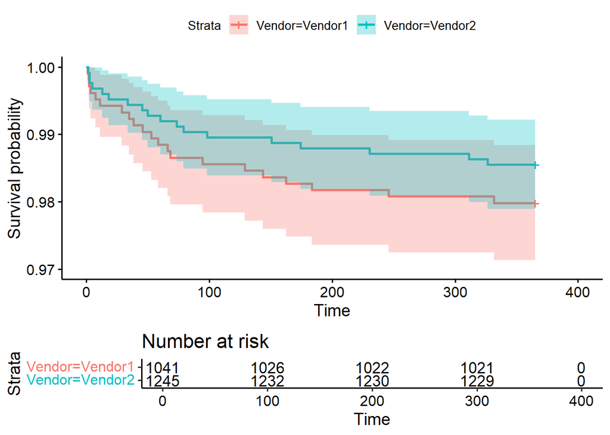

```r
#plot(fit, ylim = c(0.97,1))

ggsurvplot(fit, data = circuitPack, risk.table = T, ylim = c(0.97,1), conf.int = T)
```

```r
#Log rank test with weight = 1

survival::survdiff(survival::Surv(time = Days, event = Status, type = 'right') ~ Vendor, data = circuitPack,rho = 0) ##rho = 0 gives log rank test
```

```
## Call:
## survival::survdiff(formula = survival::Surv(time = Days, event = Status,
##     type = "right") ~ Vendor, data = circuitPack, rho = 0)
##
##                 N Observed Expected (O-E)^2/E (O-E)^2/V
## Vendor=Vendor1 22       21     20.2    0.0347    0.0724
## Vendor=Vendor2 19       18     18.8    0.0372    0.0724
##
##  Chisq= 0.1  on 1 degrees of freedom, p= 0.8
```

The above log rank test (with rho = 0) gives a p-value of 0.8. This is incorrect. Why? Because the “survdiff” function doesn’t have an argument for “weights”, which is the frequency count of the number of observations at each time. We used “weights” in the survfit function for this, but there is no such option for survdiff. Lets calculate the log rank test manually and see what we get.

The pointwise CI shows a lot of overlap (see ggsurvplot plot). So, I am expecting the logrank test p-value to be insignificant i.e (> 0.05)

I will manually prepare a table like Table 7.2 so I can try different weights suggested by Klein Moescheberger. This will also allow me to check whether comparisons through the “survMisc” package values match my manual calculations or not.

I have previously created this manual table in Exercise 7.3. So, I am going to use that same code with a few modifications.

```r
t.i <- sort(unique(circuitPack$Days[which(circuitPack$Status == 1)]))

##Fit the Kaplan Meir curve to the first group.

fit_1 <- survival::survfit(
  survival::Surv(
    time = circuitPack$Days[which(circuitPack$Vendor == "Vendor1")]
    ,
    event = circuitPack$Status[which(circuitPack$Vendor == "Vendor1")]
    ,
    type = "right"
  ) ~ 1 #Right hand formula for a single curve. It will use Turnbull iterative process for datasets containing left and right censored data.
  ,
  stype = 1 #Survival type 1 means direct estimate of survival curve. Type 2 would have been exp(-H(t))
  ,
  ctype = 1 #Cumulative Hazard type 1 is Nelson-Aalen. Type 2 is Fleming-Harrington correction for tied events.
  ,
  data = circuitPack,
  weights = Count[which(circuitPack$Vendor == "Vendor1")],
  conf.type = "log",
  conf.int = 0.95
)

summary_fit1 <- summary(fit_1)

group1 <- data.frame(Time = summary_fit1$time,
                     Events = summary_fit1$n.event,
                     At_risk = summary_fit1$n.risk)

##Fit the Kaplan Meir curve to the second group.

fit_2 <- survival::survfit(
  survival::Surv(
    time = circuitPack$Days[which(circuitPack$Vendor == "Vendor2")]
    ,
    event = circuitPack$Status[which(circuitPack$Vendor == "Vendor2")]
    ,
    type = "right"
  ) ~ 1 #Right hand formula for a single curve. It will use Turnbull iterative process for datasets containing left and right censored data.
  ,
  stype = 1 #Survival type 1 means direct estimate of survival curve. Type 2 would have been exp(-H(t))
  ,
  ctype = 1 #Cumulative Hazard type 1 is Nelson-Aalen. Type 2 is Fleming-Harrington correction for tied events.
  ,
  data = circuitPack,
  weights = Count[which(circuitPack$Vendor == "Vendor2")],
  conf.type = "log",
  conf.int = 0.95
)

summary_fit2 <- summary(fit_2)

##Get the unique "event" times in the pooled sample

t.i <- sort(unique(c(summary_fit1$time, summary_fit2$time)))

##Get the number of events and number at risk at the unique event times in the pooled sample

d.i1 <- summary(fit_1, times = t.i)$n.event
Y.i1 <- summary(fit_1, times = t.i)$n.risk

d.i2 <- summary(fit_2, times = t.i)$n.event
Y.i2 <- summary(fit_2, times = t.i)$n.risk

master_table <- data.frame(t.i = t.i,
                           Y.i1 = Y.i1,
                           d.i1 = d.i1,
                           Y.i2 = Y.i2,
                           d.i2 = d.i2)

master_table <- master_table %>%
  dplyr::mutate(Y.i = Y.i1 + Y.i2,
                d.i = d.i1 + d.i2)

master_table <- master_table %>%
  dplyr::mutate(expctd_events = ((Y.i1/Y.i)*(d.i)))

master_table <- master_table %>%
  dplyr::mutate(difference = (d.i1 - expctd_events)) %>%
  dplyr::mutate(variance = (Y.i1/Y.i)*(1-(Y.i1/Y.i))*((Y.i-d.i)/(Y.i-1))*d.i)

chi_squared.statistic <- ((sum(master_table$difference)**2))/(sum(master_table$variance))

p_value <- 1 - pchisq(chi_squared.statistic,1)
```

I get a p-value of 0.29 (which is very different from the survdiff p-value!). Thus, I do not have sufficient evidence to support the alternate hypothesis that the hazard rates are different.

Lets check the p-value of the score test in a cox proportional hazards model. This should be the same as the logrank test p-value.

```r
cox_fit <- survival::coxph(survival::Surv(time = Days, event = Status) ~ Vendor, data = circuitPack, weights = Count, ties = 'efron')

summary(cox_fit)
```

```
## Call:
## survival::coxph(formula = survival::Surv(time = Days, event = Status) ~
##     Vendor, data = circuitPack, weights = Count, ties = "efron")
##
##   n= 41, number of events= 39
##
##                  coef exp(coef) se(coef)      z Pr(>|z|)
## VendorVendor2 -0.3363    0.7144   0.3212 -1.047    0.295
##
##               exp(coef) exp(-coef) lower .95 upper .95
## VendorVendor2    0.7144        1.4    0.3806     1.341
##
## Concordance= 0.542  (se = 0.178 )
## Likelihood ratio test= 1.1  on 1 df,   p=0.3
## Wald test            = 1.1  on 1 df,   p=0.3
## Score (logrank) test = 1.11  on 1 df,   p=0.3
```

The p-value of the score test is 0.3, which closely matches the p-value that I got manually (0.29). Hence, my calculations are right.

I am more interested in the long term reliability of the components rather than their reliability at the beginning. So, I want to use the Fleming-Harrington weights (eq 7.39) with p=0 and q=1. First, I will need to fit a Kaplan Meir curve to the pooled sample.

```r
fit_pooled <- survival::survfit(
  survival::Surv(time = Days, event = Status, type = 'right') ~ 1,
  data = circuitPack,
  weights = Count,
  conf.type = "log",
  conf.int = 0.95
)

summary_fit_pooled <- summary(fit_pooled, digits = 2)

pooled_df <- data.frame(t.i_pooled = summary_fit_pooled$time, t.i_surv_pooled = summary_fit_pooled$surv) %>% dplyr::mutate(surv_pooled_minus = head(c(1,t.i_surv_pooled),-1)) #Need survival at the previous event times, as per eq 7.3.9

#Now, inner Join master_table and pooled_df

master_table <- master_table %>% dplyr::inner_join(pooled_df, by = join_by(t.i == t.i_pooled))

master_table <- master_table %>%
  dplyr::mutate(difference_weighted = (d.i1 - expctd_events)*((1-surv_pooled_minus)**1)) #Using p=0 and q =1 Fleming Harrington weights

chi_squared.statistic_FH <- ((sum(master_table$difference_weighted)**2))/(sum(master_table$variance))

(p_value_FH <- 1 - pchisq(chi_squared.statistic_FH,1))
```

```
## [1] 0.9940115
```

The p-value has increased further (0.99), which tells us that there is no difference in survival at the ends as well.

Lets try the log-rank test on the snubber dataset

```r
snubber <- read_csv("Data/Snubber.csv")
```

```r
snubber <- snubber %>%
  dplyr::mutate(Status = case_when(`Censoring Indicator` == "Failure" ~ 1, `Censoring Indicator` == "Censored" ~ 0)) %>% dplyr::rename(Cycles = `Toaster Cycles`)



#str(snubber)

#Build Kaplan Meir curve for the 2 Vendors

fit <- survival::survfit(
  survival::Surv(time = Cycles, event = Status, type = 'right') ~ Design,
  data = snubber,
  weights = Count,
  conf.type = "log",
  conf.int = 0.95
)

summary(fit, digits = 2)
```

```
## Call: survfit(formula = survival::Surv(time = Cycles, event = Status,
##     type = "right") ~ Design, data = snubber, weights = Count,
##     conf.type = "log", conf.int = 0.95)
##
##                 Design=New
##  time n.risk n.event survival std.err lower 95% CI upper 95% CI
##    47     53       1    0.981  0.0187        0.945        1.000
##    73     52       1    0.962  0.0262        0.912        1.000
##   145     46       1    0.941  0.0329        0.879        1.000
##   311     42       1    0.919  0.0390        0.846        0.999
##   490     38       1    0.895  0.0449        0.811        0.987
##   571     36       1    0.870  0.0500        0.777        0.974
##   575     34       1    0.844  0.0547        0.744        0.959
##   608     33       2    0.793  0.0622        0.680        0.925
##   630     19       1    0.751  0.0716        0.623        0.906
```

[output cut: 20 more lines]

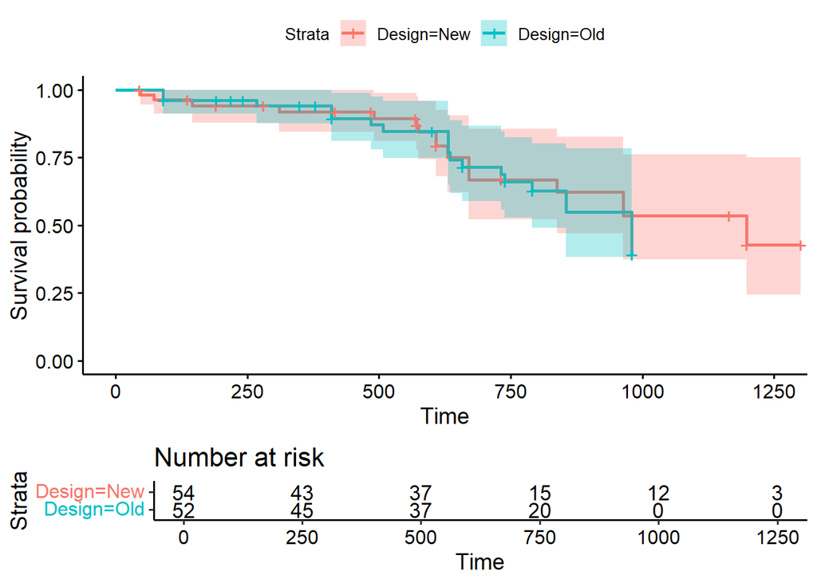

```r
#plot(fit, ylim = c(0.97,1))

ggsurvplot(fit, data = snubber, risk.table = T, conf.int = T)
```

```r
#Log rank test with weight = 1

survival::survdiff(survival::Surv(time = Cycles, event = Status, type = 'right') ~ Design, data = snubber,rho = 0) ##rho = 0 gives log rank test
```

```
## Call:
## survival::survdiff(formula = survival::Surv(time = Cycles, event = Status,
##     type = "right") ~ Design, data = snubber, rho = 0)
##
##             N Observed Expected (O-E)^2/E (O-E)^2/V
## Design=New 26       13     13.9    0.0547     0.124
## Design=Old 25       13     12.1    0.0626     0.124
##
##  Chisq= 0.1  on 1 degrees of freedom, p= 0.7
```

The log rank test, which obviously does not take into account the frequency weights, is incorrect. Let us manually build table like table 7.2.

```r
t.i <- sort(unique(snubber$Cycles[which(snubber$Status == 1)]))

##Fit the Kaplan Meir curve to the first group.

fit_1 <- survival::survfit(
  survival::Surv(
    time = snubber$Cycles[which(snubber$Design == "Old")]
    ,
    event = snubber$Status[which(snubber$Design == "Old")]
    ,
    type = "right"
  ) ~ 1 #Right hand formula for a single curve. It will use Turnbull iterative process for datasets containing left and right censored data.
  ,
  stype = 1 #Survival type 1 means direct estimate of survival curve. Type 2 would have been exp(-H(t))
  ,
  ctype = 1 #Cumulative Hazard type 1 is Nelson-Aalen. Type 2 is Fleming-Harrington correction for tied events.
  ,
  data = snubber,
  weights = Count[which(snubber$Design == "Old")],
  conf.type = "log",
  conf.int = 0.95
)

summary_fit1 <- summary(fit_1)

group1 <- data.frame(Time = summary_fit1$time,
                     Events = summary_fit1$n.event,
                     At_risk = summary_fit1$n.risk)

##Fit the Kaplan Meir curve to the second group.

fit_2 <- survival::survfit(
  survival::Surv(
    time = snubber$Cycles[which(snubber$Design == "New")]
    ,
    event = snubber$Status[which(snubber$Design == "New")]
    ,
    type = "right"
  ) ~ 1 #Right hand formula for a single curve. It will use Turnbull iterative process for datasets containing left and right censored data.
  ,
  stype = 1 #Survival type 1 means direct estimate of survival curve. Type 2 would have been exp(-H(t))
  ,
  ctype = 1 #Cumulative Hazard type 1 is Nelson-Aalen. Type 2 is Fleming-Harrington correction for tied events.
  ,
  data = snubber,
  weights = Count[which(snubber$Design == "New")],
  conf.type = "log",
  conf.int = 0.95
)

summary_fit2 <- summary(fit_2)

##Get the unique "event" times in the pooled sample

t.i <- sort(unique(c(summary_fit1$time, summary_fit2$time)))

##Get the number of events and number at risk at the unique event times in the pooled sample

d.i1 <- summary(fit_1, times = t.i, extend = T)$n.event
Y.i1 <- summary(fit_1, times = t.i, extend = T)$n.risk

d.i2 <- summary(fit_2, times = t.i)$n.event
Y.i2 <- summary(fit_2, times = t.i)$n.risk

master_table <- data.frame(t.i = t.i,
                           Y.i1 = Y.i1,
                           d.i1 = d.i1,
                           Y.i2 = Y.i2,
                           d.i2 = d.i2)

master_table <- master_table %>%
  dplyr::mutate(Y.i = Y.i1 + Y.i2,
                d.i = d.i1 + d.i2) %>%
  dplyr::filter(Y.i1 != 0 & Y.i2 != 0) #We need at least one observation at risk, as per the definition of "tau" in eq 7.3.1

master_table <- master_table %>%
  dplyr::mutate(expctd_events = ((Y.i1/Y.i)*(d.i)))

master_table <- master_table %>%
  dplyr::mutate(difference = (d.i1 - expctd_events)) %>%
  dplyr::mutate(variance = (Y.i1/Y.i)*(1-(Y.i1/Y.i))*((Y.i-d.i)/(Y.i-1))*d.i)

chi_squared.statistic <- ((sum(master_table$difference)**2))/(sum(master_table$variance))

p_value <- 1 - pchisq(chi_squared.statistic,1)
```

I am more interested in the long term reliability of the two designs rather than their reliability at the beginning. So, I want to use the Fleming-Harrington weights (eq 7.39) with p=0 and q=1. First, I will need to fit a Kaplan Meir curve to the pooled sample.

```r
fit_pooled <- survival::survfit(
  survival::Surv(time = Cycles, event = Status, type = 'right') ~ 1,
  data = snubber,
  weights = Count,
  conf.type = "log",
  conf.int = 0.95
)

summary_fit_pooled <- summary(fit_pooled, digits = 2)

pooled_df <- data.frame(t.i_pooled = summary_fit_pooled$time, t.i_surv_pooled = summary_fit_pooled$surv) %>% dplyr::mutate(surv_pooled_minus = head(c(1,t.i_surv_pooled),-1)) #Need survival at the previous event times, as per eq 7.3.9

#Now, inner Join master_table and pooled_df

master_table <- master_table %>% dplyr::inner_join(pooled_df, by = join_by(t.i == t.i_pooled))

master_table <- master_table %>%
  dplyr::mutate(difference_weighted = (d.i1 - expctd_events)*((1-surv_pooled_minus)**1)) #Using p=0 and q =1 Fleming Harrington weights

chi_squared.statistic_FH <- ((sum(master_table$difference_weighted)**2))/(sum(master_table$variance))

(p_value_FH <- 1 - pchisq(chi_squared.statistic_FH,1))
```

```
## [1] 0.8253602
```

Even the Fleming Harrington weights of p=0 and q=1 leads to an insignificant test.

ROUGH